# STAT5003

Week 6 : Cross Validation

Jaslene Lin

The University of Sydney

# Readings and R functions covered

**Important**

- **Introduction to Statistical Learning**
  - Cross validation covered in Chapter 5
- **R** functions
- `caret::createDataPartition`
  - `caret::train`
  - `caret::confusionMatrix`
  - `pROC::roc`
  - `pROC::auc`

This presentation is based on the [SOLES reveal.js Quarto template](https://github.com/usyd-soles-edu/soles-revealjs) and is licensed under a [Creative Commons Attribution 4.0 International License](http://creativecommons.org/licenses/by/4.0/).

# Resampling Methods

## 📊 Resampling Methods in Statistical Learning

- **Resampling methods** are techniques that involve repeatedly drawing samples from a training data and refitting the model on each (re)sample in order to obtain additional information about the fitted model.

### 🧪 Two Main Resampling Methods

1. **Cross-Validation (CV)**
   - Used to estimate **test error** and **select tuning parameters**
2. **Bootstrap**
   - Used primarily to **assess variability**, e.g., standard errors and confidence intervals

# Training error vs test error

## Training error vs test error

Training error is the performance metric applied to the observations used to train the model.

Test error is the average error when applying a model to predict the response on new (test) observations that were not used in the training of the model.

- Training error is usually very different in magnitude to the test error.
  - Training error can **underestimate** the test error.

## Pick the better model

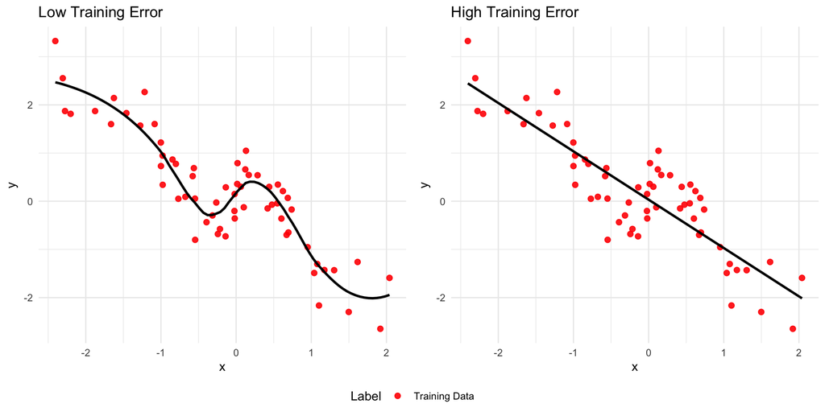

## Pick the better model

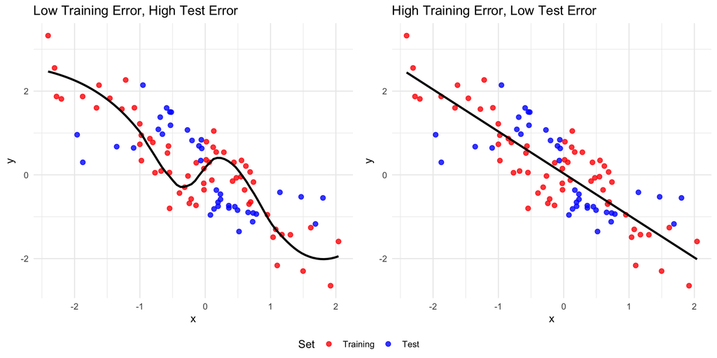

## Training error versus Test error

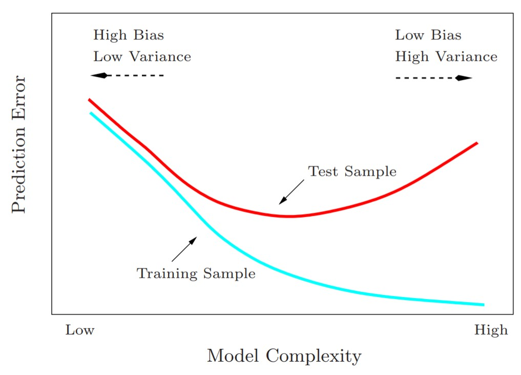

## Strategies to estimate the test error

### Desirable but not attainable (gold standard)

```
-   Use a large designated test set (often not available)
```

### Adjust the training error to estimate the test error

```
-   Common to add a penalty term to the model
    -   Bayesian information criterion (BIC)
    -   Adjusted $R^2$
```

### Cross validation

```
-   Remove or hold out a subset of observations (test set) and use
    the rest to train the model
-   Assess model performance on the test set
```

## Test set approach

- Here, we randomly divide the available set of samples into two:
  - a training set
  - a test set
- The model is fit on the training set, and the fitted model is used to predict the responses for the observations in the test set
- The resulting test-set error provides an estimate of the test error
- Typically assessed using
  - **MSE** in the case of a quantitative response (regression)
  - **Misclassification rate** in the case of a qualitative (discrete) response (classification)

## Example of the training and test split

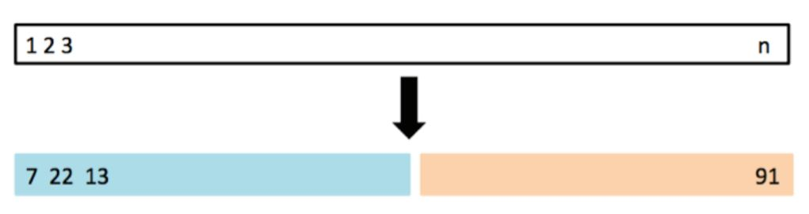

- Random split of the data into two halves
  - The left is the training indices
  - The right is the test indices

## Drawbacks of test set approach

- The estimate of the test error can be highly variable, depending on precisely which observations are included in the training set and which observations are included in the test set.
- In the test set approach, only a subset of the observations are used to fit the model.
  - This suggests that the test set error may tend to **overestimate** the test error for the model fit on the entire data set.

# $k$-fold and repeated cross validation

## Example: 5-fold

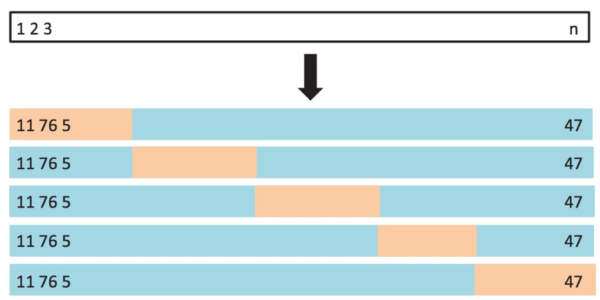

## Repeated Cross Validation

It repeats the $k$-fold CV process multiple times, each with different random splits.

It comes with **a computational cost**.

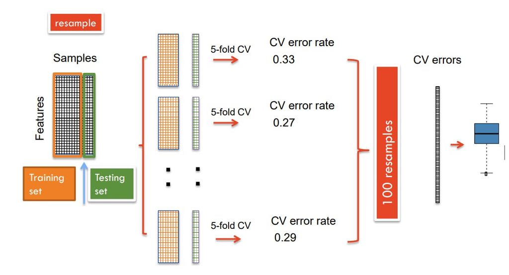

## ❓ Cross-Validation Example: What’s Wrong Here?

### Scenario:

- You are working with a **high-dimensional dataset** (many more features than observations).
- All variables are **numeric**, and you need to perform **dimension reduction** before modeling.

### CV Procedure Used:

1. Compute the **correlation** between each predictor and the response variable **using the entire dataset**.
2. Select the **top 50 variables** with the highest correlation.
3. Use these 50 variables as features and perform **k-fold cross-validation** to evaluate the model.

### ⚠️ Does this approach seem okay?

- All steps *seem* logical, but something subtle is going wrong…

## 🚫 What’s the Problem with This Approach?

### Data Leakage (Information Leak)

- You’re using the **entire dataset**, including the **test sets**, to select the top 50 features.
- This means the test set is influencing the training process — even **before the model sees it**.

### 🎯 Why This Is a Problem:

- Violates a key principle of cross-validation:  
  🔒 **The test data should be kept completely separate** from training and preprocessing.
- Leads to an **optimistic estimate** of test error.
- In high-dimensional settings, this can cause **severe overfitting** to noise.

### ✅ Correct Approach:

- Perform **feature selection inside each fold**, using **only the training portion**.
- Then evaluate the model on the test set with those selected features.

## ✅ Correct Approach:

- Split the dataset into $k$ folds
- For each iteration,
  - Perform **feature selection inside each fold**, using **(k-1) folds**.
  - Train your model using the selected variables above.
  - Run your model and record accuracy against the $k^{th}$ fold.

## Other information leakage to check

- Other things you should do it within with CV loop
  - Feature selection
  - Hyperparameter optimization
  - Missing data imputation

## Nested cross validation

### Assessing model performance while tuning hyperparameters

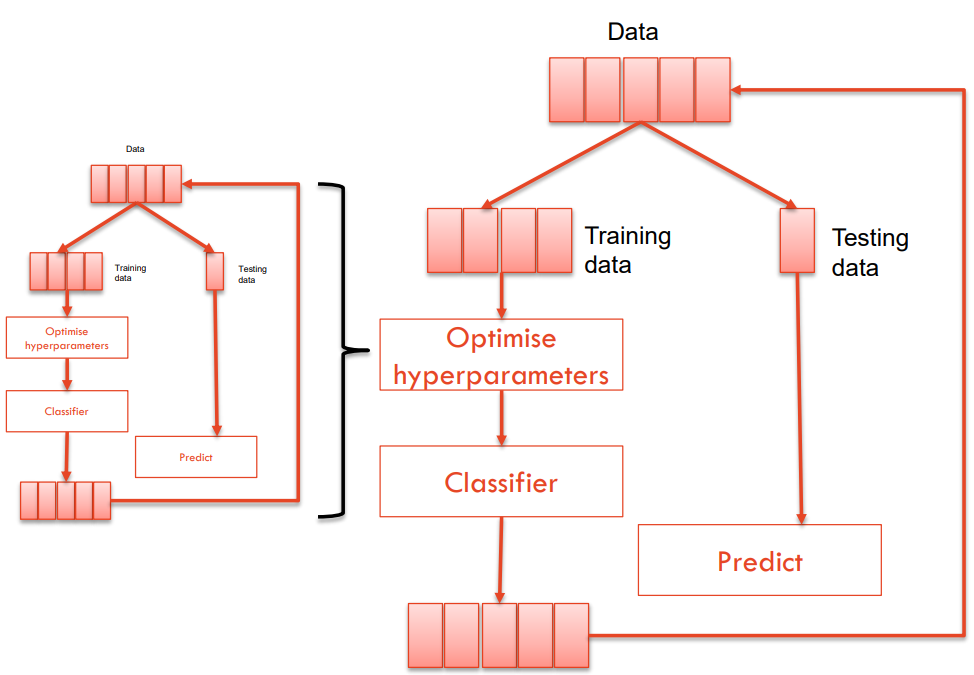

## Model Selection

- The reason for doing cross-validation is to evaluate the different models by estimating their performance on unseen data
- Example: If you need to choose between kNN, LDA, logistic regression, and SVM, then you can run each of these classification algorithms with cross-validation, and pick the one with the highest CV accuracy
- But then, you can go back to use all the data to build a final model

# Classification evaluation metrics

## Confusion Matrix

|  | Actual True | Actual False |
| --- | --- | --- |
| **Predicted** |  |  |
| True | True Positive | False Positive |
| False | False Negative | True Negative |

- True positive: positive class and predicted to be positive class
- False positive: negative class but predicted to be positive class
- False negative: positive class but predicted to be negative class
- True negative: negative class and predicted to be negative class

## Accuracy

$$\text{Accuracy} = \frac{\text{Number of Correct Predictions}}{\text{Total Number of Observations}} = \frac{TP + TN}{TP + TN + FP + FN}$$

### Limitations of Accuracy

- **Ignores the type of error**:
  - Accuracy makes no distinction about the **type** of errors being made.
  - In some cases, **errors have unequal costs**.
  - Example: Spam Filtering
    - the cost of erroneous deleting an important email is likely to be higher than incorrectly allowing a spam email past a filter.
- **Not suitable for imbalanced data**:
  - If one class is dominant, predicting the majority class yields high accuracy but poor real performance.
  - 📌 Example: Rare disease detection
    - 99% of people are healthy.
    - Predicting “healthy” for all yields 99% accuracy — but misses all actual disease cases.

## Better Alternatives

Metrics that account for class imbalance and error type:

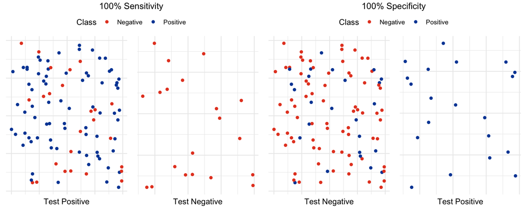

- Sensitivity (Recall) $= \frac{\text{TP}}{\text{TP} + \text{FN}} = \frac{\text{TP}}{\text{P}}$
- Specificity $= \frac{\text{TN}}{\text{TN} + \text{FP}} = \frac{\text{TN}}{\text{N}}$
- Precision $= \frac{\text{TP}}{\text{TP} + \text{FP}}$
- $F_1 = \frac{2 \text{ Precision }\times \text{ Recall}}{\text{ Precision }+ \text{ Recall}}$ (Harmonic mean)
- $\text{GM}= \sqrt{ \text{ Precision }\times \text{ Recall}}$ (Geometric mean)

## 📈 Receiver Operating Characteristic (ROC) Curve

- The **ROC curve** is a graphical tool used to evaluate the performance of a **binary classifier**.

`PimaIndiansDiabetes`

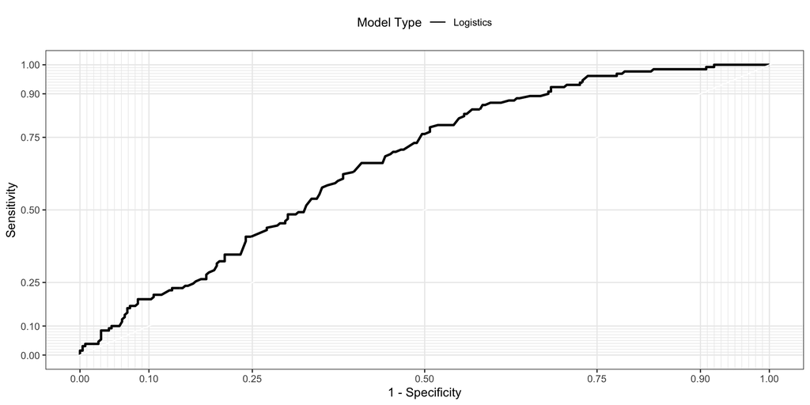

- It plots the **Sensitivity** against the **False Positive Rate (1 - Specificity)** at **various threshold settings**.
- Each point on the ROC curve corresponds to a different **decision threshold**.
- The closer the curve is to the **top-left corner**, the better the model.

## Why Use the ROC Curve?

- Helps compare **classification models**.
- Useful when classes are **imbalanced**.
- The **Area Under the Curve (AUC)** summarises the overall performance:
  - AUC = 1: Perfect model
  - AUC = 0.5: No better than random guessing

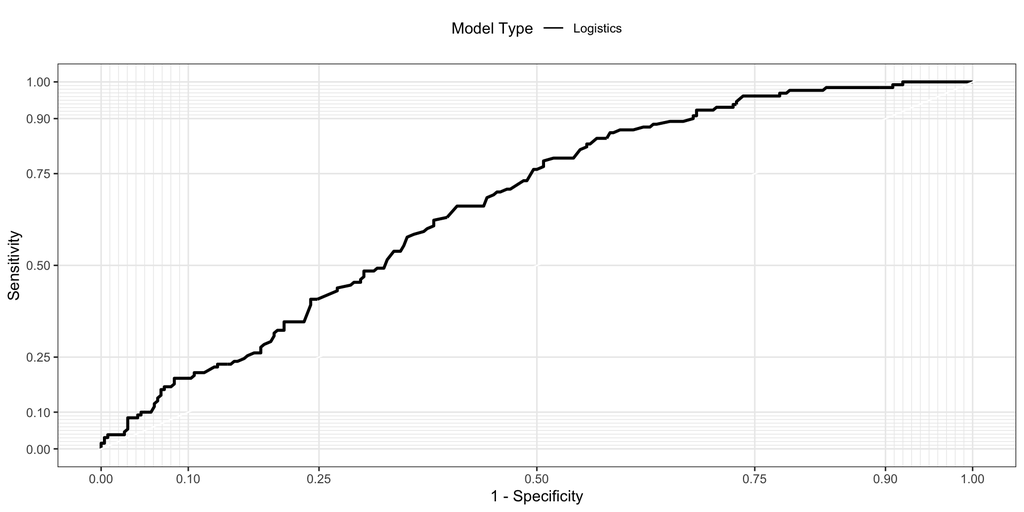

## Comparing ROC curves

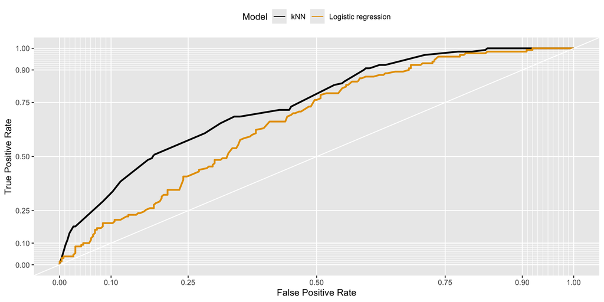

## Multi-class classfication

- We have discussed performance measures for binary classification
- Performance measured like precision, recall, $F_1$, and AUC may be generalised to classification problems with more than 2 labels
  - Useful for your group project
  - [A kaggle blog for reading (code in Python)](https://www.kaggle.com/code/nkitgupta/evaluation-metrics-for-multi-class-classification)